# Notebook for R (Lec 2-3)

### List

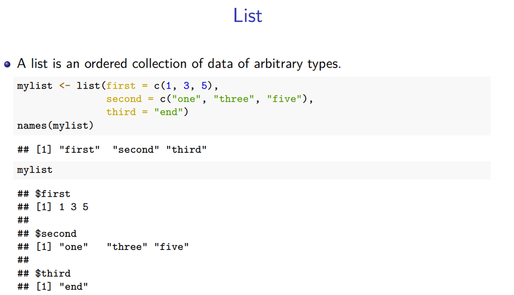

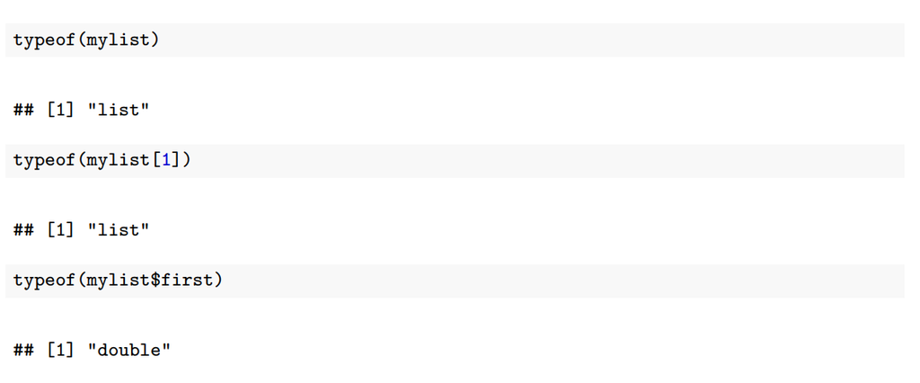

```r
a <- list(a = 1:3,
          b = "a stgring",
          c = pi,
          d = list(-1,-5) )
a[1:2]
```

```
## $a
## [1] 1 2 3
##
## $b
## [1] "a stgring"
```

```r
a[4]
```

```
## $d
## $d[[1]]
## [1] -1
##
## $d[[2]]
## [1] -5
```

```r
a[[4]]
```

```
## [[1]]
## [1] -1
##
## [[2]]
## [1] -5
```

```r
a[[4]][1]
```

```
## [[1]]
## [1] -1
```

```r
a[[4]][[1]]
```

```
## [1] -1
```

### Data Frame

#### 1. Creation

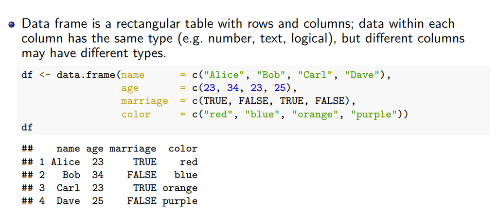

```r
time <- 1:3
value1 <- c(1, 2, 2)
value2 <- c(2, 0, 2)

data <- data.frame(time, value1, value2) #一定要用长度相同的向量
data
```

```
##   time value1 value2
## 1    1      1      2
## 2    2      2      0
## 3    3      2      2
```

#### 2. Data Access

```r
# 从索引访问第2行
data[2,]
```

```
##   time value1 value2
## 2    2      2      0
```

```r
# 从列名访问列
data$value1
```

```
## [1] 1 2 2
```

```r
# 从行名访问行
data["3", ]
```

```
##   time value1 value2
## 3    3      2      2
```

```r
# 访问指定的其他行列
# 只能通过索引操作，不能从行名、列名操作，行名、列名都是字符类型，不支持-操作符，如data[-"2",]、data[,-"value1"]
data[-2,]
```

```
##   time value1 value2
## 1    1      1      2
## 3    3      2      2
```

#### 3. Gets the row name and column name

```r
rownames(data)
```

```
## [1] "1" "2" "3"
```

```r
colnames(data)
```

```
## [1] "time"   "value1" "value2"
```

```r
# 通过赋值可以对行名、列名进行更改
```

## Function

### Basic R function

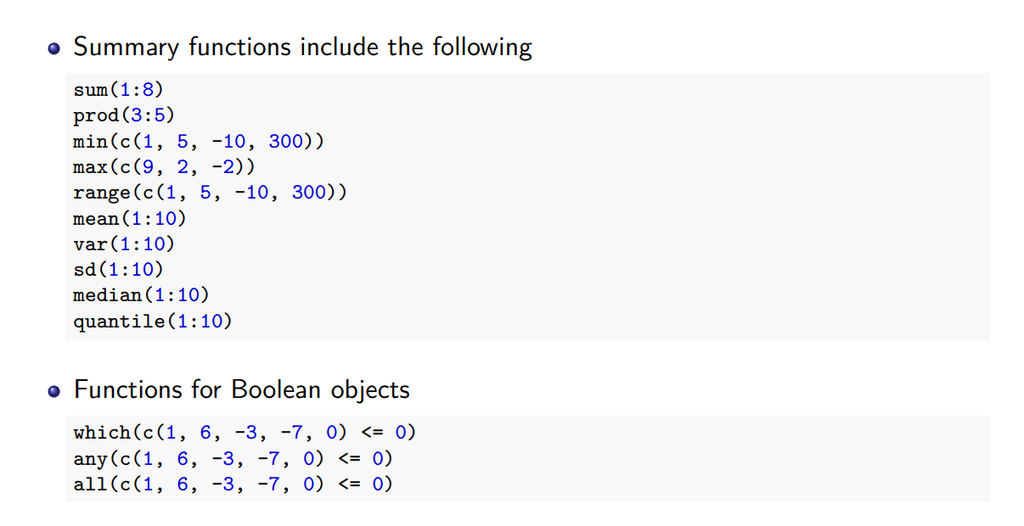

### Exercise

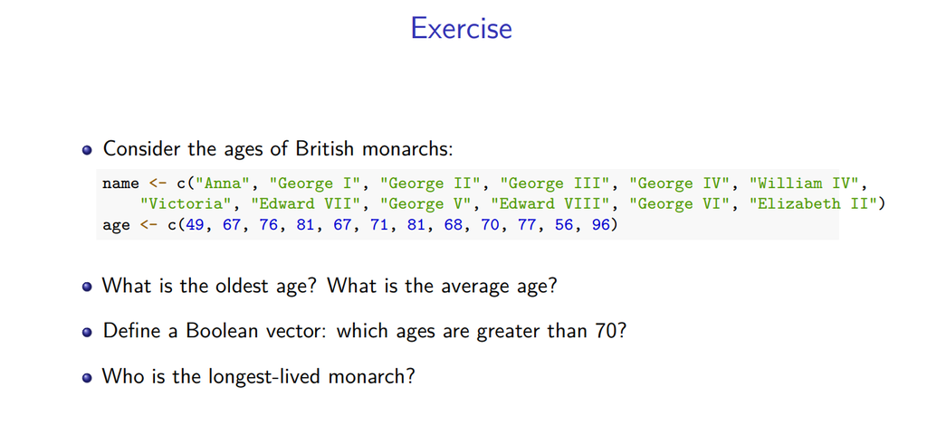

```r
name <- c("Anna", "George I", "George II", "George III", "George IV", "William IV",
"Victoria", "Edward VII", "George V", "Edward VIII", "George VI", "Elizabeth II")
age <- c(49, 67, 76, 81, 67, 71, 81, 68, 70, 77, 56, 96)

#第一题
max(age)
```

```
## [1] 96
```

```r
mean(age)
```

```
## [1] 71.58333
```

```r
#第二题
age > 70 #Be careful about the boolean vector!
```

```
##  [1] FALSE FALSE  TRUE  TRUE FALSE  TRUE  TRUE FALSE FALSE  TRUE FALSE  TRUE
```

```r
#第三题
name[which(age==96)]
```

```
## [1] "Elizabeth II"
```

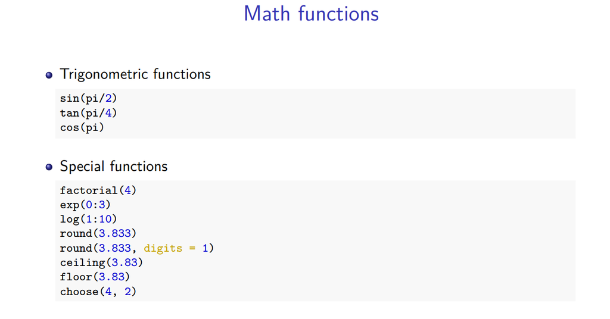

### Sort function

```r
x <- c(13,14,12,11,15)
y <- sort(x) #从小到大排序
y
```

```
## [1] 11 12 13 14 15
```

```r
r <- rank(x) #每个位置的数的排序位置（从小到大）
r
```

```
## [1] 3 4 2 1 5
```

```r
o <- order(x) #从小到大排序后每个数对应原向量的位置
o
```

```
## [1] 4 3 1 2 5
```

```r
x[o]
```

```
## [1] 11 12 13 14 15
```

### Combine matrices or arrys

- rbind() 按行来合并

```r
x <- c(1:5)
y <- x*2
rbind(x,y)
```

```
##   [,1] [,2] [,3] [,4] [,5]
## x    1    2    3    4    5
## y    2    4    6    8   10
```

- cbind() 按列来合并

```r
cbind(x,y)
```

```
##      x  y
## [1,] 1  2
## [2,] 2  4
## [3,] 3  6
## [4,] 4  8
## [5,] 5 10
```

### Exercise

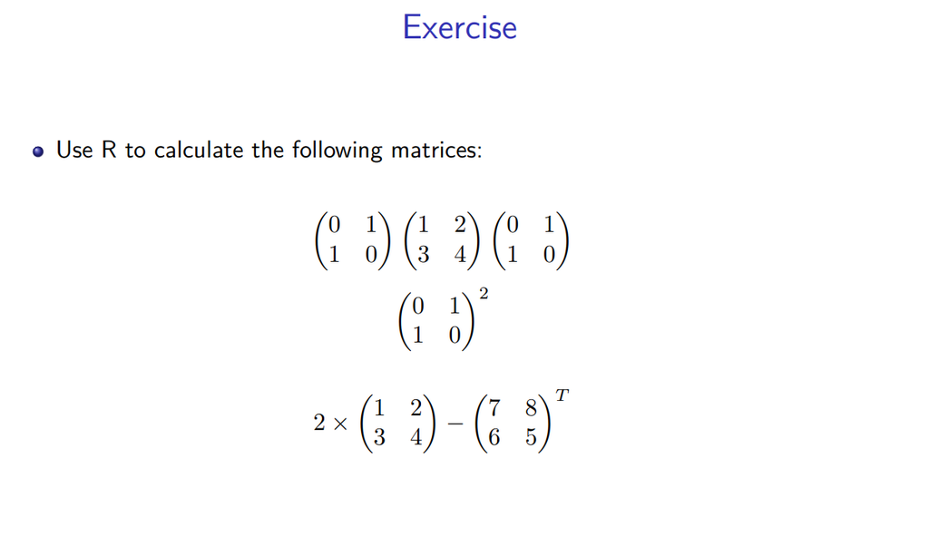

```r
# Exercise 1
(a <- matrix(c(0,1,1,0),nrow=2))
```

```
##      [,1] [,2]
## [1,]    0    1
## [2,]    1    0
```

```r
(b <- matrix(c(1,3,2,4),nrow=2))
```

```
##      [,1] [,2]
## [1,]    1    2
## [2,]    3    4
```

```r
(c <- matrix(c(0,1,1,0),nrow=2))
```

```
##      [,1] [,2]
## [1,]    0    1
## [2,]    1    0
```

```r
a %*% b %*% c
```

```
##      [,1] [,2]
## [1,]    4    3
## [2,]    2    1
```

```r
#Exercise 2
a %*% a
```

```
##      [,1] [,2]
## [1,]    1    0
## [2,]    0    1
```

```r
#Exercise 3
d <- matrix(c(7,6,8,5),nrow=2)
t(d)
```

```
##      [,1] [,2]
## [1,]    7    6
## [2,]    8    5
```

```r
2 * b - t(d)
```

```
##      [,1] [,2]
## [1,]   -5   -2
## [2,]   -2    3
```

### Matrix calculation: Squires matrics

[figure not shown]

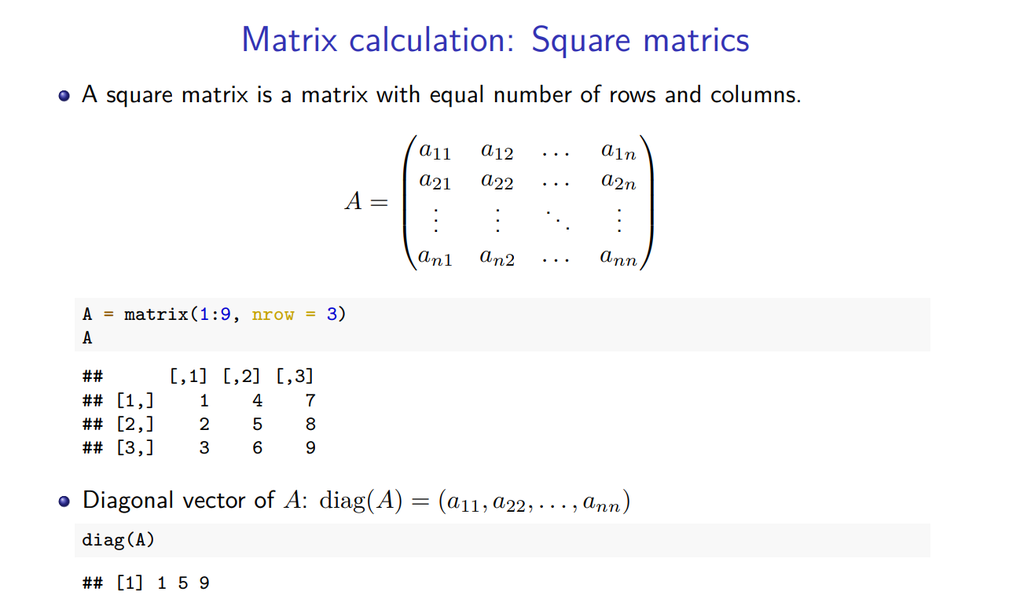

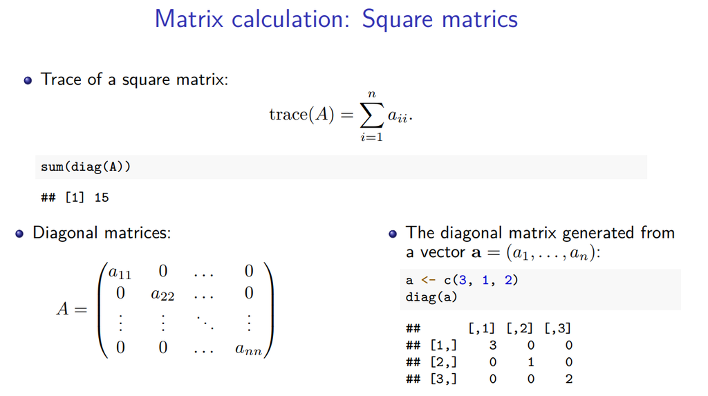

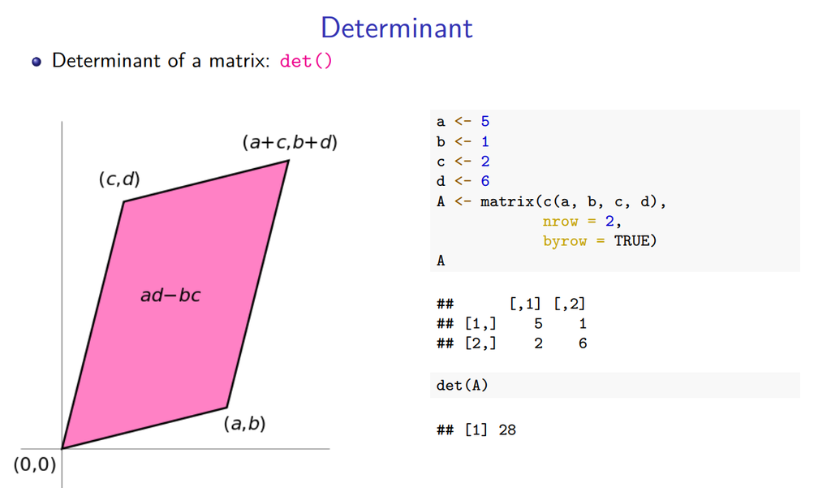

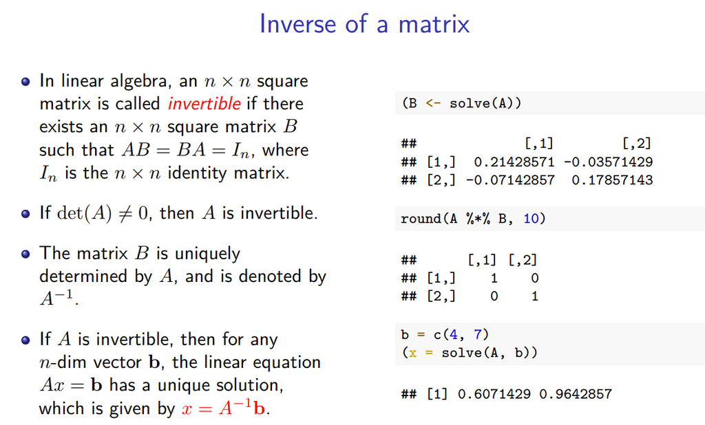

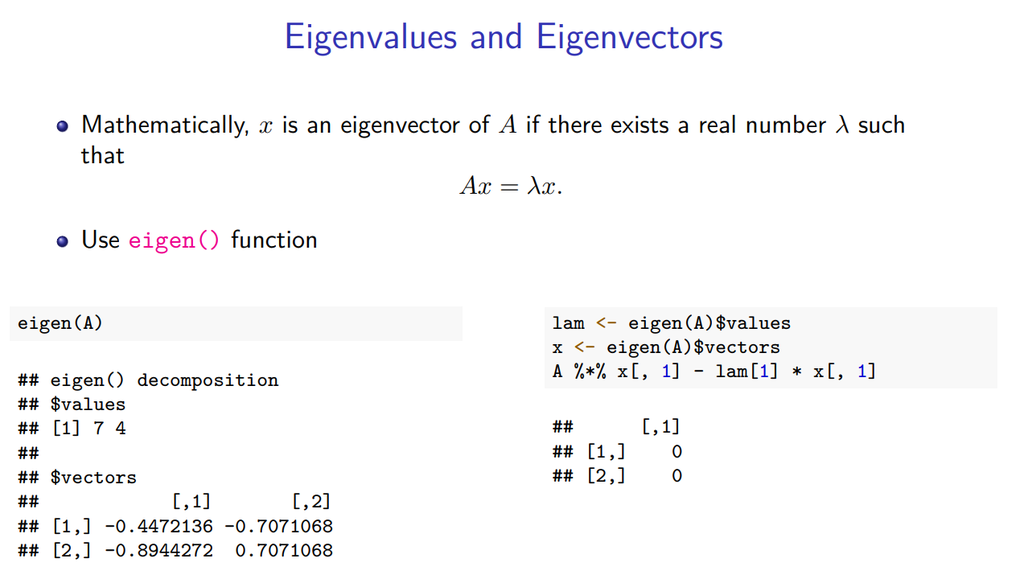

### Exercise

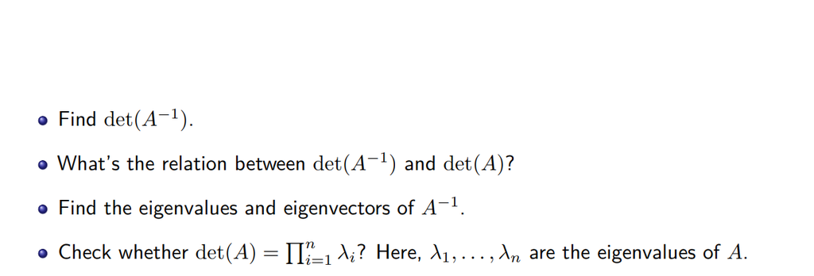

```r
#Exercise 1
A <- matrix(c(5,2,1,6),nrow=2)
(B <- solve(A))
```

```
##             [,1]        [,2]
## [1,]  0.21428571 -0.03571429
## [2,] -0.07142857  0.17857143
```

```r
det(B)
```

```
## [1] 0.03571429
```

```r
#Exercise 2
det(A) * det(B)
```

```
## [1] 1
```

```r
#Exercise 3
eigen(B)
```

```
## eigen() decomposition
## $values
## [1] 0.2500000 0.1428571
##
## $vectors
##            [,1]      [,2]
## [1,]  0.7071068 0.4472136
## [2,] -0.7071068 0.8944272
```

```r
det(A) == prod(eigen(A)$values)
```

```
## [1] FALSE
```

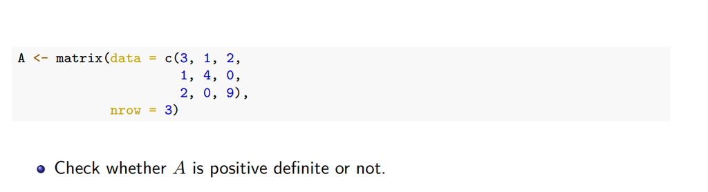

```r
A <- matrix(c(3,1,2,
              1,4,0,
              2,0,9),
            nrow=3)
M <- any(eigen(A)$values>0)
if(M){
  print("A is positive definite!")
} else{
  print("A is not positive definite!")
}
```

```
## [1] "A is positive definite!"
```

### Function of characters

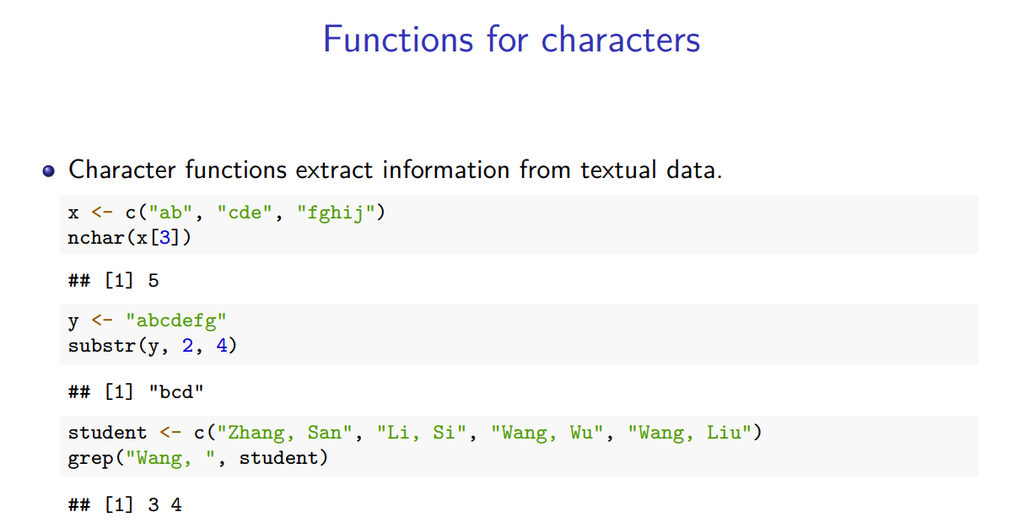

grep()能对向量中特定条件的元素进行查询

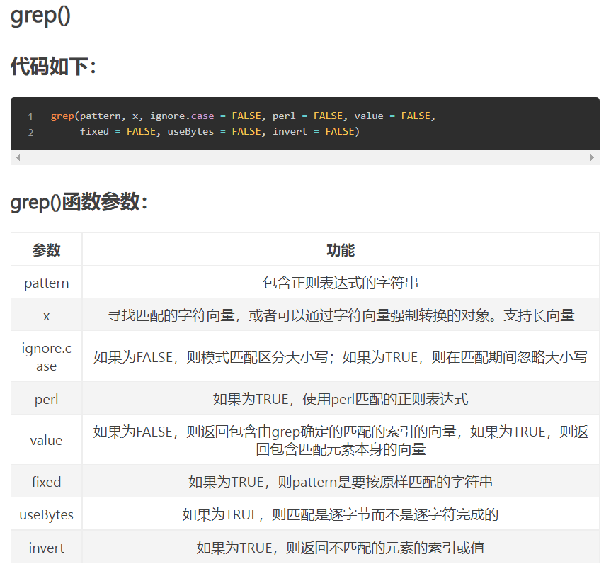

### apply() Family

首先我们创建一个简单的数值矩阵

```r
data <- matrix(1:20,5,4)
data
```

```
##      [,1] [,2] [,3] [,4]
## [1,]    1    6   11   16
## [2,]    2    7   12   17
## [3,]    3    8   13   18
## [4,]    4    9   14   19
## [5,]    5   10   15   20
```

首先让我们从apply()开始

#### apply()

apply函数的结构是apply(X,MARGINE,FUN,…)

这里，

- X是指我们要对其进行操作的数据集
- MARGIEN是指我们需指定是按行还是按列来进行操作
- MARGIEN = 1 代表按行操作； MARGIEN = 2 代表按列操作；MARGIEN = 1:2 代表对全体操作
- FUN是指我们将要对X进行的操作函数

一个简单的示例：

```r
mean_rows <- apply(data,1,mean)
mean_rows
```

```
## [1]  8.5  9.5 10.5 11.5 12.5
```

```r
sum_cols <- apply(data,2,sum)
sum_cols
```

```
## [1] 15 40 65 90
```

```r
all_sqrt <- apply(data,1:2,sqrt)
all_sqrt
```

```
##          [,1]     [,2]     [,3]     [,4]
## [1,] 1.000000 2.449490 3.316625 4.000000
## [2,] 1.414214 2.645751 3.464102 4.123106
## [3,] 1.732051 2.828427 3.605551 4.242641
## [4,] 2.000000 3.000000 3.741657 4.358899
## [5,] 2.236068 3.162278 3.872983 4.472136
```

apply家族也可以用于多参数的函数：

```r
fn = function(x1, x2, x3)
{
    return(x1^2 + x2 * x1 + x3)
}
b = 2
c = 1

# apply along each row:
row_fn <- apply(data, 1, fn, x2 = b, x3 = c)
row_fn
```

```
##      [,1] [,2] [,3] [,4] [,5]
## [1,]    4    9   16   25   36
## [2,]   49   64   81  100  121
## [3,]  144  169  196  225  256
## [4,]  289  324  361  400  441
```

```r
# apply along each column:
col_fn <- apply(data, 2, fn, x2 = b, x3 = c)
col_fn
```

```
##      [,1] [,2] [,3] [,4]
## [1,]    4   49  144  289
## [2,]    9   64  169  324
## [3,]   16   81  196  361
## [4,]   25  100  225  400
## [5,]   36  121  256  441
```

## Import data

### Keyboard import

- 我们可以创建一个表格，并对表格进行编辑:

```r
mydata <- data.frame(
age = numeric(0),
gender = character(0),
weight = numeric(0)
)
## mydata <- edit(mydata)
```

- 或者直接用代码输入

```r
mydatatxt <- "
age gender weight
25 m 166
30 f 115
18 f 120
"
mydata <- read.table(header = TRUE, text = mydatatxt)
```

### From a delimited text file: read.table()

- The format is

```r
my_data <- read.table(file,options)
```

### Exercise

Student grades: csv file (此处直接以文本显示，实际操作中需将文件放入R所读取的文件包中)

StudentID,First,Last,Math,Science,Social Studies

011,Bob,Smith,90,80,67

012,Jane,Weary,75,,80

010,Dan,“Thornton, III”,65,75,70

040,Mary,“O’Leary”,90,95,92

```r
grades <- read.table("studentgrades.csv",
header=TRUE,
row.names="StudentID",
sep=",")  ##sep 代表两个数据之间的间隔符号，从而将数据区分开
```

- Build-in data sets

R里有很多数据包可以调用数据

```r
data(iris)
data(mtcars, package = "datasets")
```

**attach** and **detach** functions:

```r
## If we directly input Sepal_Length    Error!
attach(iris)
Sepal.Length
```

```
##   [1] 5.1 4.9 4.7 4.6 5.0 5.4 4.6 5.0 4.4 4.9 5.4 4.8 4.8 4.3 5.8 5.7 5.4 5.1
##  [19] 5.7 5.1 5.4 5.1 4.6 5.1 4.8 5.0 5.0 5.2 5.2 4.7 4.8 5.4 5.2 5.5 4.9 5.0
##  [37] 5.5 4.9 4.4 5.1 5.0 4.5 4.4 5.0 5.1 4.8 5.1 4.6 5.3 5.0 7.0 6.4 6.9 5.5
##  [55] 6.5 5.7 6.3 4.9 6.6 5.2 5.0 5.9 6.0 6.1 5.6 6.7 5.6 5.8 6.2 5.6 5.9 6.1
##  [73] 6.3 6.1 6.4 6.6 6.8 6.7 6.0 5.7 5.5 5.5 5.8 6.0 5.4 6.0 6.7 6.3 5.6 5.5
##  [91] 5.5 6.1 5.8 5.0 5.6 5.7 5.7 6.2 5.1 5.7 6.3 5.8 7.1 6.3 6.5 7.6 4.9 7.3
## [109] 6.7 7.2 6.5 6.4 6.8 5.7 5.8 6.4 6.5 7.7 7.7 6.0 6.9 5.6 7.7 6.3 6.7 7.2
## [127] 6.2 6.1 6.4 7.2 7.4 7.9 6.4 6.3 6.1 7.7 6.3 6.4 6.0 6.9 6.7 6.9 5.8 6.8
## [145] 6.7 6.7 6.3 6.5 6.2 5.9
```

```r
detach(iris)
```

## Basic Graphs

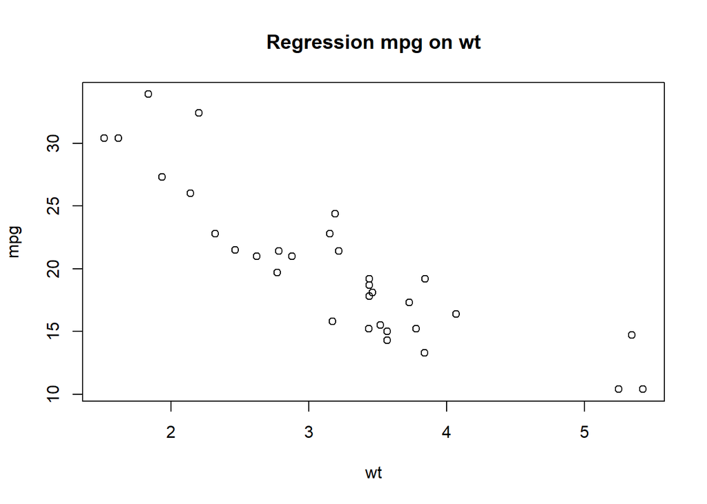

```r
attach(mtcars)
plot(wt,mpg)
title("Regression mpg on wt")
```

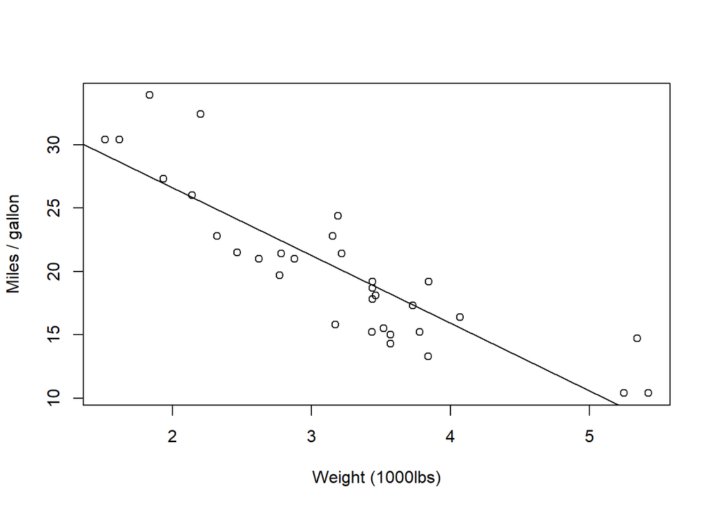

```r
plot(wt, mpg, xlab = "Weight (1000lbs)", ylab = "Miles / gallon") ## 改变横纵坐标名称
abline(lm(mpg~wt)) ## 画出线性回归线
```

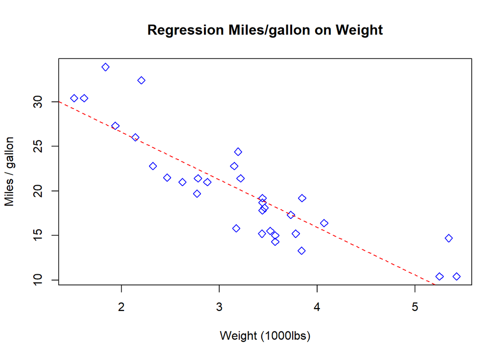

```r
plot(wt, mpg, col = "blue", pch = 5,
xlab = "Weight (1000lbs)", ylab = "Miles / gallon")
title("Regression Miles/gallon on Weight")
abline(lm(mpg~wt), col = "red", lty = 2)   ##改变颜色，形状
```

```r
detach(mtcars)
```